# Military Deployment Network analysis

Emil Staszewski

## Введение

Военное развертывание, как один из инструментов ведения внешней политики, в контексте последних геополитиеских событий, приобретает особую значимость.

Словарь военных и связанных с ними терминов определяет *военное развертывание* как перемещение вооруженных сил и их инфраструктуры тылового обеспечения по всему миру.

Исторически и концептуально явление оформляется в годы Холодной Войны, за это время претерпев множетсво изменений:

- В эпоху Холодной Войны ключевой целью развертывания было военное сдерживание противника. Сеть развертываний поделена на два крупных враждующих лагеря - СССР и США, военные контингенты которых были распространены по всему миру с целью остановить распространения влияния враждебного лагеря и удержать регионы в своей зоне влияния
- После Холодной Войны сеть развертываний перестает быть биполярной - возникаю новые центры. СССР (то есть Россиия) после выводы войск из Европы временно перестает быть крупным центром развертывания. В бывших колониях даже после получения независимости все еще стоят крупные контигенты из Франции и Великобритании. Развертывание становится более ситуативным - помимо задач удержания влияния в регионе появляются новые:
  - Помощь мирового сообществам странам, находящимся в гуманитарном кризисе. (Например Балканским странам в 90е гг)
  - Антитеррористическая операция
  - Миротворческие операции

Загрузим необходимые библиотеки

```r
library(readxl)
library(tidyverse)
library(modelsummary)
library(haven)
options(scipen=999)
library(sjPlot)
library(tidygraph)
library(igraph)
library(ggraph)

library(data.table)
library(states)
library(demcon)
library(intergraph)
library(ergm)


colors3=c('#e6194b', '#3cb44b', '#ffe119', '#4363d8', '#f58231', '#911eb4', '#46f0f0', '#f032e6', '#bcf60c', '#fabebe', '#008080', '#e6beff', '#9a6324', '#fffac8', '#800000', '#aaffc3', '#808000', '#ffd8b1', '#000075', 'gold', '#ffffff', '#000000')
```

Загрузим дата сеты, содержащие данные о развертывании, численности национальных армий, военных расходах.

```r
balance <- read_excel('~/DH project minor/balance.xlsx')
decoder1=read_excel('~/Диффузия Code/data/coding.xlsx',sheet=1)
decoder2=read_excel('~/Диффузия Code/data/coding.xlsx',sheet=2)

continent1=read_excel('~/Диффузия Code/data/continets.xls',sheet=1)
continent2=read_excel('~/Диффузия Code/data/continets.xls',sheet=2)


balance %>% left_join(decoder1,by='ccode1') %>%
  left_join(decoder2,by='ccode2')->balance


balance %>% left_join(continent1,by='deployer')->balance
balance %>% left_join(continent2,by='receptor')->balance


balance$troops = as.numeric(balance$Troops)
balance$joinl=paste(balance$year,balance$ccode1,sep='')

milper=read_dta('~/Диффузия Code/data/NMC-60-abridged.dta')
milper$milper=milper$milper*1000

milper$joinl=paste(milper$year,milper$ccode,sep='')

milper %>% dplyr::select(milper,milex,tpop,joinl)->milperj

balance %>%
  left_join(milperj,by='joinl')->balance
```

Загружаем V-DEM датасет, для режимов стран отправителей войск.

```r
vdem <- demcon::get_vdem(write_out = FALSE)


vdem$regime=case_when(
  vdem$v2x_regime==0  ~ 'autocracy',
  vdem$v2x_regime>1 ~ 'democracy'
)



vdem$deployer_regime = vdem$regime
vdem$receptor_regime = vdem$regime

balance$code_join1=paste(balance$year,balance$deployer,sep='')
balance$code_join2=paste(balance$year,balance$receptor,sep='')

vdem$code_join1=paste(vdem$year,vdem$country_name,sep='')
vdem$code_join2=paste(vdem$year,vdem$country_name,sep='')

vdem %>% select(code_join1,deployer_regime,e_gdp)->vdem_regime_deployer
vdem %>% select(code_join2,receptor_regime)->vdem_regime_receptor

balance %>% left_join(vdem_regime_deployer,by='code_join1')->balance
balance %>% left_join(vdem_regime_receptor,by='code_join2')->balance


communities_countries <- read.csv('~/Диффузия Code/data/communities.csv')

balance %>% left_join(communities_countries,by='ccode1')->balance
```

## Данные:

В финальный соединеный датасет входят следующие переменные:

- Deployer - страна отправитеть (cowc1 и ccode1 ее числовой и буквенный коды)
- Receptor - страна, принимающая войска (cowc1 и ccode1 ее числовой и буквенный коды)
- Troops - количество войск, отправленных страной
- year - год отправления
- Additional_info - дполнительная информация о развертывании (военная техника, воинские подразделения и т д)
- deployer_regime - политический режим страны отправителя. Упрощенная версия кодировки V-DEM, в нашем случае она бинарная: либо демократия либо автократия
- deployer_continent - континент страны отправителя
- receptor_continent - континент страны получателя
- UN_mission - бинарная переменная - либо развертывание как миссия ООН либо нет
- NATO_mission - бинарная переменная, является ли развертывание операцией НАТО или нет

*Исследовательскй вопрос:*

Какие факторы определяют образование связей между странами с сети военного развертывания в 1985-2020 годах?

### *Гипотезы*

- **Демократия на штыках** - в разные периоды будет наблюдаться разная гомофилия (или даже обратный процесс), то есть демократии не всегда будут отправлять войска в демократические страны. Такие крупные страны как США или Россия могут способствовать удержанию своих режимов и зон влияния **на штыках** отправленных войск.
- Децентрализация - после Холодной войны начинается увеличивается континентальная гомофилия - страны отправляют свои войска в регионы своего же континента
- Между странами не существует гомофилии по уровню ВВП, страны с высоким ВВП чаще отправляют войска в страны с низким ВВП.

Сначала создадим общий граф, и с помощью метрик опишем динамику его развитию.

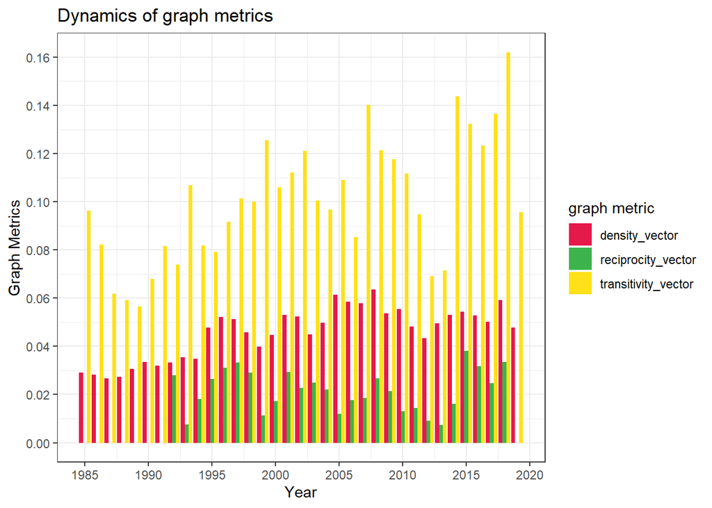

```r
years <- c(1985:2019)


density_vector <- c()

for(x in 1985:2019){
  balance %>% filter(year==x) %>%
    dplyr::select(cowc1,cowc2,troops) %>% na.omit() %>%
    graph_from_data_frame() %>% graph.density()->new_value
  density_vector <- c(density_vector,new_value)

}


transitivity_vector <- c()

for(i in 1985:2019){
  balance %>% filter(year==i) %>%
    dplyr::select(cowc1,cowc2,troops) %>% na.omit() %>%
    graph_from_data_frame() %>% transitivity()->new_value
  transitivity_vector <- c(transitivity_vector,new_value)

}



reciprocity_vector <- c()

for(i in 1985:2019){
  balance %>% filter(year==i) %>%
    dplyr::select(cowc1,cowc2,troops) %>% na.omit() %>%
    graph_from_data_frame() %>% reciprocity()->new_value
  reciprocity_vector <- c(reciprocity_vector,new_value)

}

mod_table <- data.frame(years,density_vector,reciprocity_vector,transitivity_vector)

mod_table %>%
  pivot_longer(
    cols =c('density_vector':'transitivity_vector'),
    names_to = 'graph metric',
    values_to = 'value'
  )->graph_metric_long

graph_metric_long %>%
  ggplot(aes(years,value,fill=`graph metric`))+
  geom_bar(stat='identity',position = position_dodge())+
  scale_x_continuous(breaks = scales::pretty_breaks(n = 10)) +
  scale_y_continuous(breaks = scales::pretty_breaks(n = 10))+
  labs(title = 'Dynamics of graph metrics ',y='Graph Metrics',x='Year')+
  scale_fill_manual(values = colors3)+
  theme_bw()
```

Посмотрим динамику сети на графах(в ходе рисования графиков были отдельно концептуально выделены 3 крупных сообщества - Европейский Альянс, США и их союзники, Россия с Африканскими и Азиатскими странами, и другие страны Азии, Африки)

**Красным выделены автократии, синим - демократии**

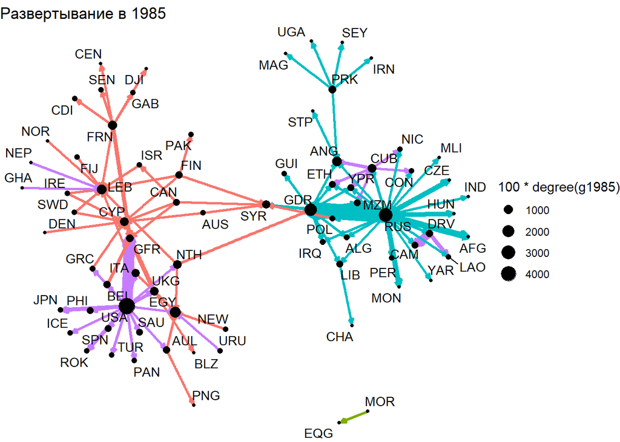

```r
balance %>% filter(year==1985) %>%
  dplyr::select(cowc1,cowc2,troops,community_name,deployer_regime) %>% na.omit() %>% as_tbl_graph()-> g1985


ggraph(g1985, layout = "fr") +
  geom_edge_link( arrow = arrow(type = "closed",
                                              angle = 25,
                                              length = unit(1.5, 'mm')),
                 end_cap = circle(0.5, 'mm'),
                 aes(width=troops/10,color=community_name) , show.legend = FALSE) +
  geom_node_point(aes(size=100*degree(g1985))) +
  geom_node_text(aes(label = name), repel = TRUE, size = 3.7) +
  labs(title ='Развертывание в 1985')+
  theme_void()
```

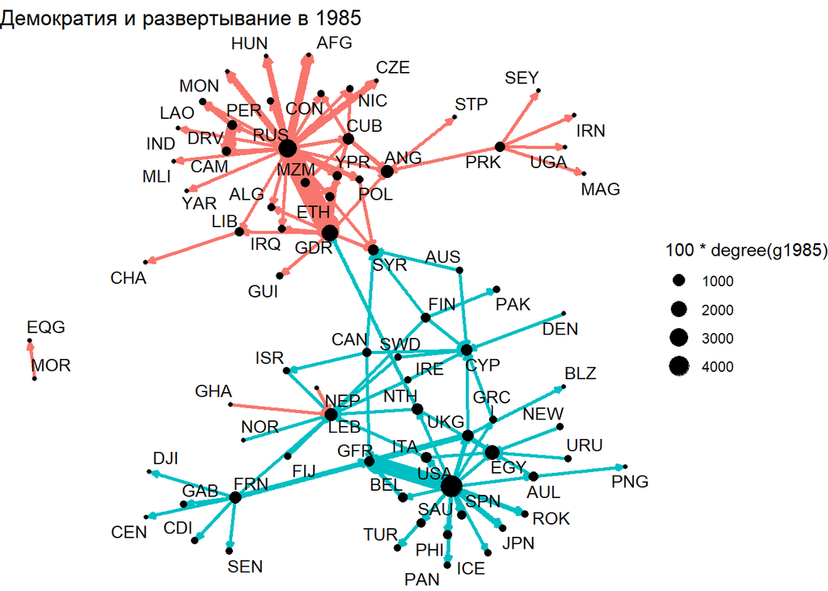

```r
ggraph(g1985, layout = "fr") +
  geom_edge_link( arrow = arrow(type = "closed",
                                              angle = 25,
                                              length = unit(1.5, 'mm')),
                 end_cap = circle(0.5, 'mm'),
                 aes(width=troops/10,color=deployer_regime) , show.legend = FALSE) +
  geom_node_point(aes(size=100*degree(g1985))) +
  geom_node_text(aes(label = name), repel = TRUE, size = 3.7) +
  labs(title ='Демократия и развертывание в 1985')+
  theme_void()
```

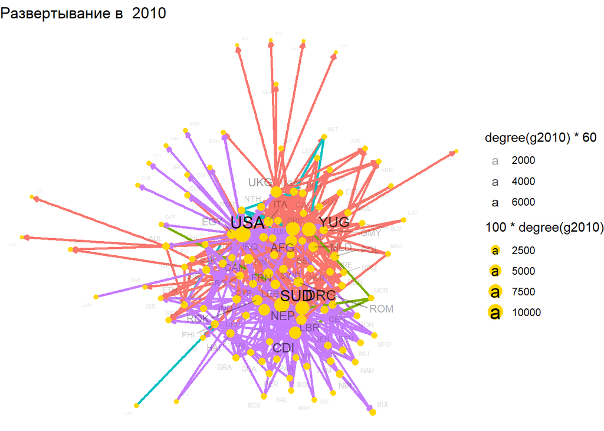

```r
balance %>% filter(year==2010) %>%
  dplyr::select(cowc1,cowc2,troops,community_name,deployer_regime) %>%
  na.omit()%>% as_tbl_graph()-> g2010


ggraph(g2010, layout = "fr") +
  geom_edge_link( arrow = arrow(type = "closed",
                                angle = 25,
                                length = unit(1.5, 'mm')),
                  end_cap = circle(0.5, 'mm'),
                  aes(width=troops/10,color=community_name) , show.legend = FALSE) +
  geom_node_point(color='gold',aes(size=100*degree(g2010))) +
  geom_node_text(aes(label = name,size=degree(g2010)*60,alpha=degree(g2010)*60), repel = TRUE) +
  labs(title ='Развертывание в  2010')+
  theme_void()
```

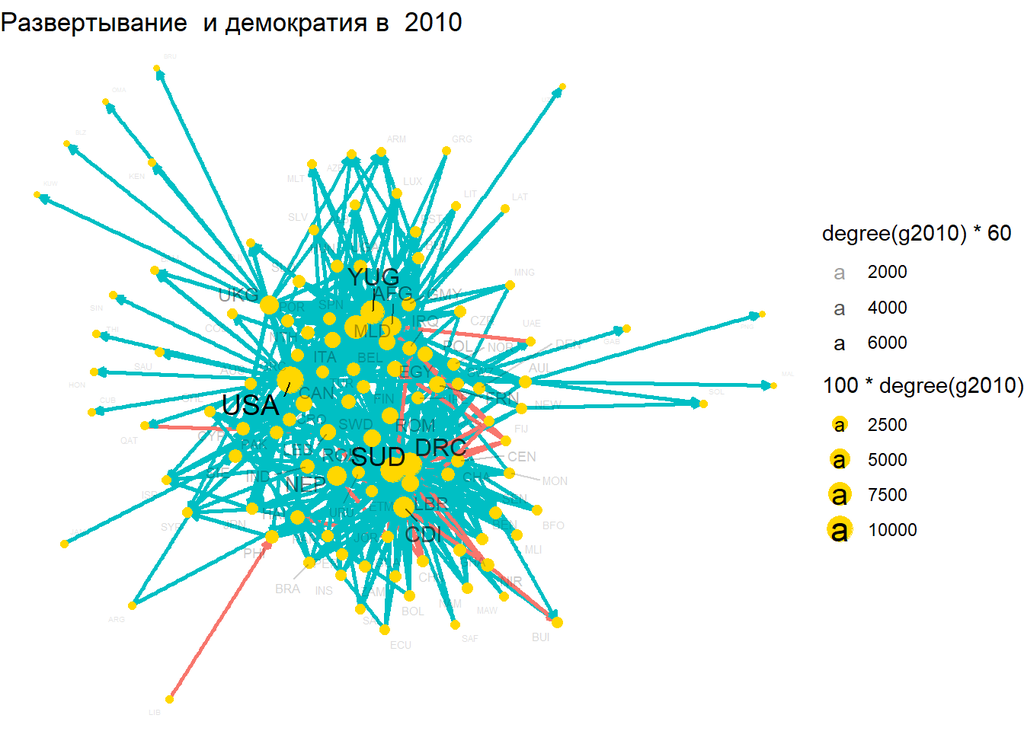

```r
ggraph(g2010, layout = "fr") +
  geom_edge_link( arrow = arrow(type = "closed",
                                angle = 25,
                                length = unit(1.5, 'mm')),
                  end_cap = circle(0.5, 'mm'),
                  aes(width=troops/10,color=deployer_regime) , show.legend = FALSE) +
  geom_node_point(color='gold',aes(size=100*degree(g2010))) +
  geom_node_text(aes(label = name,size=degree(g2010)*60,alpha=degree(g2010)*60), repel = TRUE) +
  labs(title ='Развертывание  и демократия в  2010')+
  theme_void()
```

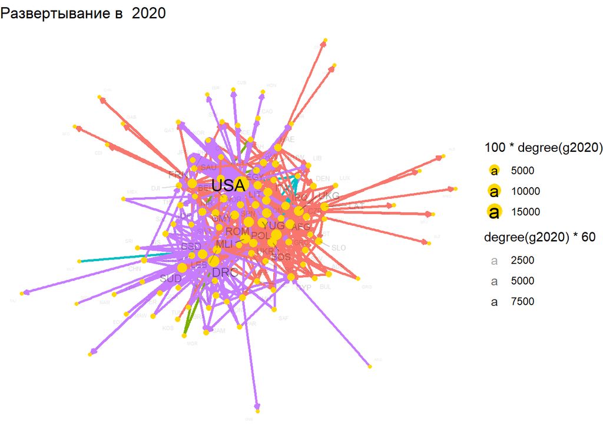

```r
balance %>% filter(year==2020) %>%
  dplyr::select(cowc1,cowc2,troops,community_name,deployer_regime) %>%
  na.omit()%>% as_tbl_graph()-> g2020


ggraph(g2020, layout = "fr") +
  geom_edge_link( arrow = arrow(type = "closed",
                                angle = 25,
                                length = unit(1.5, 'mm')),
                  end_cap = circle(0.5, 'mm'),
                  aes(width=troops/10,color=community_name) , show.legend = FALSE) +
  geom_node_point(color='gold',aes(size=100*degree(g2020))) +
  geom_node_text(aes(label = name,size=degree(g2020)*60,alpha=degree(g2020)*60), repel = TRUE) +
  labs(title ='Развертывание в  2020')+
  theme_void()
```

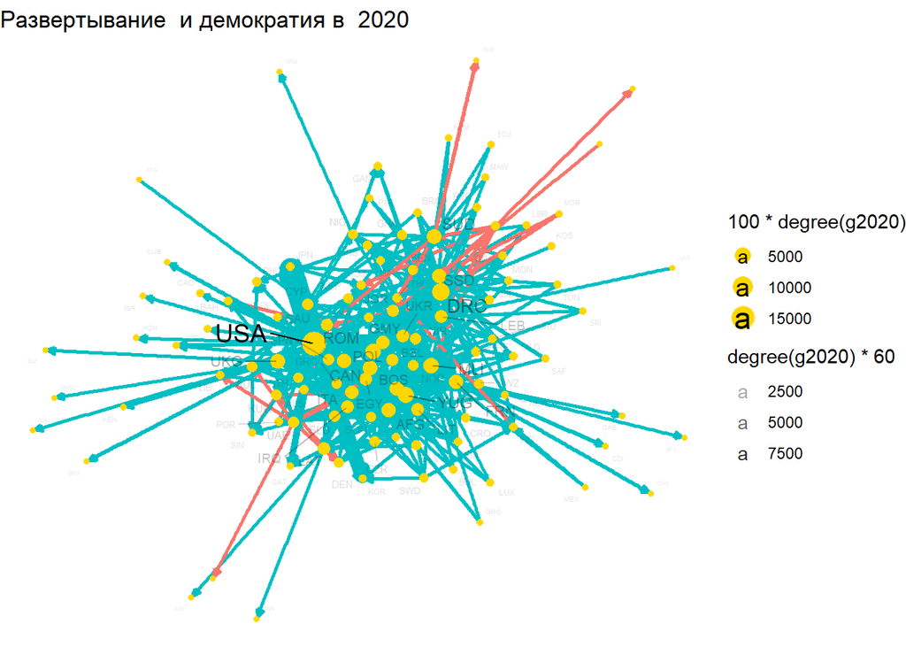

```r
ggraph(g2020, layout = "fr") +
  geom_edge_link( arrow = arrow(type = "closed",
                                angle = 25,
                                length = unit(1.5, 'mm')),
                  end_cap = circle(0.5, 'mm'),
                  aes(width=troops/10,color=deployer_regime) , show.legend = FALSE) +
  geom_node_point(color='gold',aes(size=100*degree(g2020))) +
  geom_node_text(aes(label = name,size=degree(g2020)*60,alpha=degree(g2020)*60), repel = TRUE) +
  labs(title ='Развертывание  и демократия в  2020')+
  theme_void()
```

```r
years <- c(1985:2020)

degrees <- data.frame()
betweennesses <- data.frame()
degree_out <- data.frame()
closenesses <- data.frame()
for(i in years){
  balance %>% filter(year==i) %>% dplyr::select(ccode1,ccode2,troops) %>%
    graph_from_data_frame()->g
  n_d <- as.data.frame(degree(g))
  year=c(rep(i,nrow(n_d)))
  n_d$join=paste(year,rownames(n_d),sep='')
  degrees <- rbind(degrees,n_d)

  b_d <- as.data.frame(betweenness(g))
  b_d$join=paste(year,rownames(b_d),sep='')
  betweennesses <- rbind(betweennesses,b_d)

  do_d <- as.data.frame(degree(g,mode='in'))
  do_d$join=paste(year,rownames(do_d),sep='')
  degree_out <- rbind(degree_out,do_d)

  c_d <- as.data.frame(closeness(g))
  c_d$join=paste(year,rownames(c_d),sep='')
  closenesses <- rbind(closenesses,c_d)



}

balance$join=paste(balance$year,balance$ccode1,sep='')


balance %>% left_join(degrees,by='join') %>%
  left_join(betweennesses,by='join') %>%
  left_join(degree_out,by='join') %>%
  left_join(closenesses,by='join')->balance

balance %>%
  rename(degree =  `degree(g)`,
         betweenness=`betweenness(g)`,
         degree_in=`degree(g, mode = "in")`,
        closeness =`closeness(g)`)->balance
```

*топ стран по числу степеней с годами*

```r
tab1= balance  %>% arrange(-degree) %>% select(year,deployer) %>% unique() %>% head(n=10)

tab1 %>% knitr::kable("markdown")
```

| year | deployer |
| --- | --- |
| 2007 | United States of America |
| 2020 | United States of America |
| 2009 | Sudan |
| 2018 | United States of America |
| 2008 | Sudan |
| 2015 | United States of America |
| 2006 | United States of America |
| 2013 | Democratic Republic of the Congo |
| 2014 | United States of America |
| 2010 | United States of America |

*топ стран по числу степеней*

```r
tab2= balance  %>% arrange(-degree) %>% select(deployer) %>% unique() %>% head(n=10)

tab2  %>% knitr::kable("markdown")
```

| deployer |
| --- |
| United States of America |
| Sudan |
| Democratic Republic of the Congo |
| Yugoslavia/Serbia |
| Burundi |
| Ivory Coast |
| Georgia |
| Nepal |
| Bosnia and Herzegovina |
| Lithuania |

*топ стран получателей войск с годами*

```r
tab21 = balance  %>% arrange(-degree_in) %>% select(year,deployer) %>% unique() %>% head(n=10)

tab21 %>% knitr::kable("markdown")
```

| year | deployer |
| --- | --- |
| 2009 | Sudan |
| 2008 | Sudan |
| 2013 | Democratic Republic of the Congo |
| 2011 | Democratic Republic of the Congo |
| 2009 | Democratic Republic of the Congo |
| 2008 | Yugoslavia/Serbia |
| 2014 | Democratic Republic of the Congo |
| 2010 | Democratic Republic of the Congo |
| 2005 | Yugoslavia/Serbia |
| 2007 | Yugoslavia/Serbia |

*топ стран получателей войск*

```r
tab3 = balance  %>% arrange(-degree_in) %>% select(deployer) %>% unique() %>% head(n=10)

tab3  %>% knitr::kable("markdown")
```

| deployer |
| --- |
| Sudan |
| Democratic Republic of the Congo |
| Yugoslavia/Serbia |
| Ivory Coast |
| Burundi |
| Georgia |
| Bosnia and Herzegovina |
| Lithuania |
| Nepal |
| Mali |

*топ стран объединяющих крупные сообщества*

```r
tab5 = balance  %>% arrange(-betweenness) %>% select(deployer) %>% unique() %>% head(n=10)
tab5 %>% knitr::kable("markdown")
```

| deployer |
| --- |
| Saudi Arabia |
| Kuwait |
| Sudan |
| United States of America |
| Canada |
| Singapore |
| Latvia |
| Turkey |
| Italy |
| Russia |

*топ стран наиболее близких к остальным*

```r
tab6 = balance  %>% arrange(-closeness) %>% select(deployer) %>% unique() %>% head(n=10)

tab6 %>% knitr::kable("markdown")
```

| deployer |
| --- |
| Belgium |
| Denmark |
| Greece |
| Norway |
| Turkey |
| Iran |
| Israel |
| Libya |
| Morocco |
| Syria |

Ожидаемые высокие значения по числу степеней у США,страны Африки как горячие точки также обладают высокими занчениями, неожиданно - маленькая Литва. Последнее возможно связано с тем, что Литва находится на границе соприкосновения альянсов Западной Европы и России, НАТО и ОДКБ.

Крупнейшие страны получатели в основном горячие точки Африки и Азии, находящиеся в состоянии гуманитарного кризиса Сербия, Босния , а также снова Литва.

В топы стран объединяющих подсообшества как и ожидалось вошли такие крупные геополитические игроки как США, Росссия,Саудовская Аравия. Топ стран, через которых проходят наиболее короткие пути возглавляет Бельгия, Дания и Греция, действительно в своих регионах они занимают стратегические местоположения.

Перейдем к проверке наших гипотез, разделим сеть на 3 периода:

- Эпоху Холодной Войны (до 1992 года)
- Период после Холодной Войны и до 2014 года 2014 год и дальше

```r
balance %>%
  filter(year <1992) %>%
  select(cowc1,cowc2,year,troops,deployer_regime,receptor_regime,milper,deployer_continent,
         e_gdp) %>%
  na.omit()->Cold_War

Cold_War_graph=Cold_War %>% graph_from_data_frame()



Cold_War_graph= Cold_War_graph %>% set_vertex_attr( "deployer_regime", index = V(Cold_War_graph), as.factor(Cold_War$deployer_regime)) %>%
  set_vertex_attr( "milper", index = V(Cold_War_graph), as.numeric(Cold_War$milper)) %>%
  set_vertex_attr( "e_gdp", index = V(Cold_War_graph), as.numeric(Cold_War$e_gdp)) %>%
  set_vertex_attr( "deployer_continent", index = V(Cold_War_graph), as.factor(Cold_War$deployer_continent))


library(network)

Cold_War_network <- asNetwork(Cold_War_graph)

balance %>%
  filter(year >1992 & year <2014) %>%
  select(cowc1,cowc2,year,troops,deployer_regime,receptor_regime,milper,deployer_continent,
         e_gdp) %>%
  na.omit()->period_1992_2014

period_1992_2014_graph=period_1992_2014 %>% graph_from_data_frame()



period_1992_2014_graph= period_1992_2014_graph %>% set_vertex_attr( "deployer_regime", index = V(period_1992_2014_graph), as.factor(period_1992_2014$deployer_regime)) %>%
  set_vertex_attr( "milper", index = V(period_1992_2014_graph), as.numeric(period_1992_2014$milper)) %>%
  set_vertex_attr( "e_gdp", index = V(period_1992_2014_graph), as.numeric(period_1992_2014$e_gdp)) %>%
  set_vertex_attr( "deployer_continent", index = V(period_1992_2014_graph), as.factor(period_1992_2014$deployer_continent))



period_1992_2014_network <- asNetwork(period_1992_2014_graph)

balance %>%
  filter(year >=2014) %>%
  select(cowc1,cowc2,year,troops,deployer_regime,receptor_regime,milper,deployer_continent,
         e_gdp) %>%
  na.omit()->after_2014

after_2014_graph=after_2014 %>% graph_from_data_frame()



after_2014_graph= after_2014_graph %>% set_vertex_attr( "deployer_regime", index = V(after_2014_graph), as.factor(after_2014$deployer_regime)) %>%
  set_vertex_attr( "milper", index = V(after_2014_graph), as.numeric(after_2014$milper)) %>%
  set_vertex_attr( "e_gdp", index = V(after_2014_graph), as.numeric(after_2014$e_gdp)) %>%
  set_vertex_attr( "deployer_continent", index = V(after_2014_graph), as.factor(after_2014$deployer_continent))



after_2014_network <- asNetwork(after_2014_graph)
```

```r
model1<- ergm(Cold_War_network ~ edges+nodematch('deployer_regime')+absdiff("milper")+absdiff('e_gdp')+
                nodematch('deployer_continent'))
summary(model1)
```

```
## Call:
## ergm(formula = Cold_War_network ~ edges + nodematch("deployer_regime") +
##     absdiff("milper") + absdiff("e_gdp") + nodematch("deployer_continent"))
##
## Maximum Likelihood Results:
##
##                                   Estimate    Std. Error MCMC % z value
## edges                        -3.1142136859  0.2880306925      0 -10.812
## nodematch.deployer_regime     0.5809418059  0.2059298145      0   2.821
## absdiff.milper               -0.0000002799  0.0000001176      0  -2.380
## absdiff.e_gdp                 0.0000004156  0.0000004739      0   0.877
## nodematch.deployer_continent -1.2105465834  0.3388491524      0  -3.573
##                              Pr(>|z|)
## edges                        < 0.0001 ***
## nodematch.deployer_regime    0.004786 **
## absdiff.milper               0.017295 *
## absdiff.e_gdp                0.380510
## nodematch.deployer_continent 0.000354 ***
## ---
## Signif. codes:  0 '***' 0.001 '**' 0.01 '*' 0.05 '.' 0.1 ' ' 1
##
##      Null Deviance: 8983  on 6480  degrees of freedom
##  Residual Deviance: 1630  on 6475  degrees of freedom
##
## AIC: 1640  BIC: 1674  (Smaller is better. MC Std. Err. = 0)
```

```r
model2<- ergm(period_1992_2014_network ~ edges+nodematch('deployer_regime')+absdiff("milper")+absdiff('e_gdp')+
                nodematch('deployer_continent'))
summary(model2)
```

```
## Call:
## ergm(formula = period_1992_2014_network ~ edges + nodematch("deployer_regime") +
##     absdiff("milper") + absdiff("e_gdp") + nodematch("deployer_continent"))
##
## Maximum Likelihood Results:
##
##                                    Estimate     Std. Error MCMC % z value
## edges                        -3.35292834835  0.08328749098      0 -40.257
## nodematch.deployer_regime     0.50044468255  0.08598459091      0   5.820
## absdiff.milper                0.00000030209  0.00000008088      0   3.735
## absdiff.e_gdp                 0.00000052822  0.00000055575      0   0.950
## nodematch.deployer_continent -0.63496867052  0.09182312685      0  -6.915
##                              Pr(>|z|)
## edges                        < 0.0001 ***
## nodematch.deployer_regime    < 0.0001 ***
## absdiff.milper               0.000188 ***
## absdiff.e_gdp                0.341882
## nodematch.deployer_continent < 0.0001 ***
## ---
## Signif. codes:  0 '***' 0.001 '**' 0.01 '*' 0.05 '.' 0.1 ' ' 1
##
##      Null Deviance: 25078  on 18090  degrees of freedom
##  Residual Deviance:  6905  on 18085  degrees of freedom
##
## AIC: 6915  BIC: 6954  (Smaller is better. MC Std. Err. = 0)
```

```r
model3<- ergm(after_2014_network ~ edges+nodematch('deployer_regime')+absdiff("milper")+absdiff('e_gdp')+
                nodematch('deployer_continent'))
summary(model3)
```

```
## Call:
## ergm(formula = after_2014_network ~ edges + nodematch("deployer_regime") +
##     absdiff("milper") + absdiff("e_gdp") + nodematch("deployer_continent"))
##
## Maximum Likelihood Results:
##
##                                 Estimate  Std. Error MCMC % z value Pr(>|z|)
## edges                        -6.35997500  2.36236234      0  -2.692   0.0071 **
## nodematch.deployer_regime             NA  0.00000000      0      NA       NA
## absdiff.milper               -0.00002211  0.00002995      0  -0.738   0.4603
## absdiff.e_gdp                 0.00001846  0.00002478      0   0.745   0.4564
## nodematch.deployer_continent  3.13980138  2.36054082      0   1.330   0.1835
## ---
## Signif. codes:  0 '***' 0.001 '**' 0.01 '*' 0.05 '.' 0.1 ' ' 1
##
##      Null Deviance: 12643  on 9120  degrees of freedom
##  Residual Deviance:  2944  on 9115  degrees of freedom
##
## AIC: 2954  BIC: 2990  (Smaller is better. MC Std. Err. = 0)
```

Соберем модели в один лист, чтоб сранить результаты

```r
models <- list(model1,model2,model3)



modelsummary(models)
```

|  | Model 1 | Model 2 | Model 3 |
| --- | --- | --- | --- |
| edges | -3.114 | -3.353 | -6.360 |
|  | (0.288) | (0.083) | (2.362) |
| nodematch.deployer_regime | 0.581 | 0.500 |  |
|  | (0.206) | (0.086) |  |
| absdiff.milper | -0.0000003 | 0.0000003 | -0.00002 |
|  | (0.0000001) | (8e-08) | (0.00003) |
| absdiff.e_gdp | 0.0000004 | 0.0000005 | 0.00002 |
|  | (0.0000005) | (0.0000006) | (0.00002) |
| nodematch.deployer_continent | -1.211 | -0.635 | 3.140 |
|  | (0.339) | (0.092) | (2.361) |
| Num.Obs. | 6480 | 18090 | 9120 |
| AIC | 1640.1 | 6914.7 | 2954.2 |
| BIC | 1674.0 | 6953.7 | 2989.8 |

Попробуев выявить динамику роста региональных организаций внутри континентов.

Начнем с важной границы сопррикосновения нескольких альянсов - Восточной Европы.Еще в первой четверти XX века Юзеф Пилсудсукий предлагал альянс “Междуморье”,который должен был включать в себя Польшу, Украину, Беларусь, Литву, Латвию, Эстонию, Молдову, Венгрию, Румынию, Югославию, Чехословакию, а также, возможно, Финляндию.

В 2015 году об этой идее вспомнил президент Польши Анджи Дуда в контексте постепенно обострения конфликта России и Украины. В 2016 году состоялся саммит возможных будущих членов - Эстонии, Латвии, Литвы, Польши, Чехии, Словакии, Австрии, Венгрии, Словении, Хорватии, Румынии, Болгарии. В контексте событий 24 февраля Украина также становится потенциальным членом - так как НАТО не может напрямую вмешиваться в конфликт, “Междуморье” может сыграть важную роль в Восточной Европе.

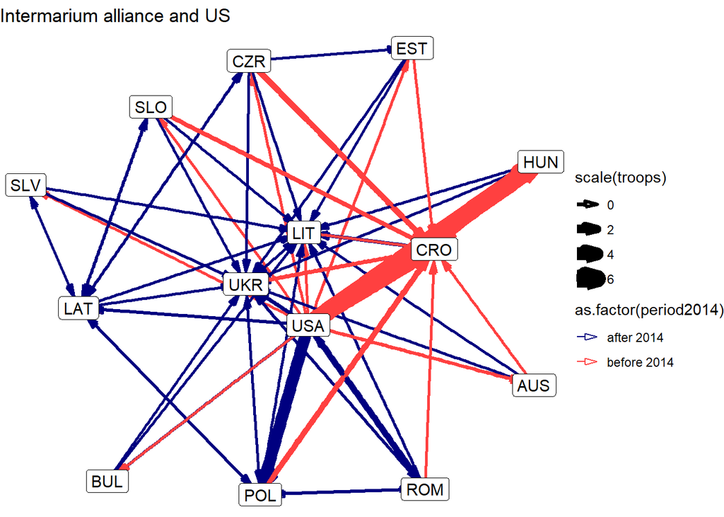

```r
library(igraph)

balance$period2014 <- ifelse(balance$year<2014,'before 2014','after 2014')

intermarium_vec <- c(366,367,368,369,316,317,310,305,349,344,360,355,290,2)

balance %>% filter(ccode1 %in% intermarium_vec & ccode2 %in% intermarium_vec) %>%
  select(cowc1,cowc2,year,troops,period2014) %>% graph_from_data_frame()->intermarium_net


intermarium_tbl=intermarium_net %>% as_tbl_graph()

ggraph(intermarium_tbl) +
  geom_edge_link(aes(color=as.factor(period2014),width=scale(troops)),
                 end_cap = circle(3, 'mm'),
                 arrow = arrow(angle = 15, type = "closed", length = unit(3, 'mm'))) +
  geom_node_point(color='blue') +
  geom_node_label(aes(label=name), size = 4)  +
  scale_edge_color_manual(values=c('navyblue','brown1'))+
  ggtitle('Intermarium alliance and US')+
  theme_void()
```

Как видно на графике после 2014 года возникает множестов новых связей, хоть США и играет значительную роль и они отправляют наибольшее число войск, можно предпологать будущее гипотетическое существование “Междуморья” как самостоятельной части НАТО.

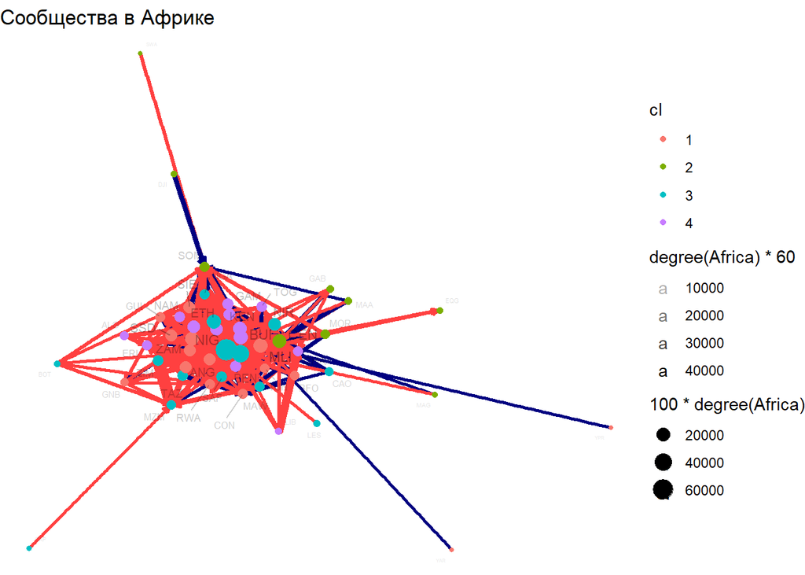

```r
balance %>% filter(deployer_continent=='Africa' & receptor_continent=='Africa') %>%
  dplyr::select(cowc1,cowc2,troops,period2014) %>% na.omit() %>% as_tbl_graph()-> Africa
wc <- cluster_fast_greedy(as.undirected(Africa))
table <- cbind(wc$membership, wc$names)
table = as.data.frame(table)
V(Africa)$cl = as.character(table$V1[match(V(Africa)$name, table$V2)])


ggraph(Africa, layout = "fr") +
  geom_edge_link( arrow = arrow(type = "closed",
                                              angle = 25,
                                              length = unit(1.5, 'mm')),
                 end_cap = circle(0.5, 'mm'),
                 aes(width=troops/10,color=as.factor(period2014)) , show.legend = FALSE) +
  geom_node_point(aes(color = cl,size=100*degree(Africa))) +
  geom_node_text(aes(label = name,size=degree(Africa)*60,alpha=degree(Africa)*60), repel = TRUE) +
  scale_edge_color_manual(values=c('navyblue','brown1'))+
  labs(title ='Сообщества в Африке')+
  theme_void()
```

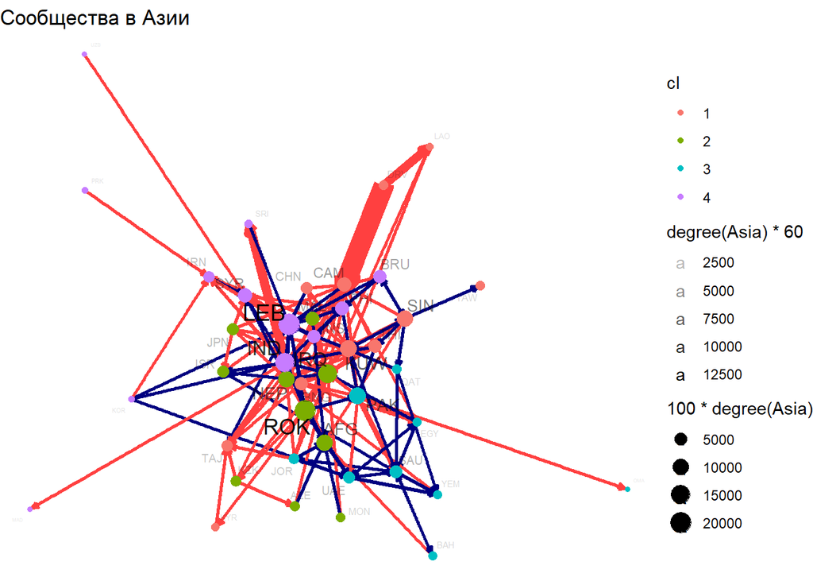

```r
balance %>% filter(deployer_continent=='Asia' & receptor_continent=='Asia') %>%
  dplyr::select(cowc1,cowc2,troops,period2014) %>% na.omit() %>% as_tbl_graph()-> Asia
wc <- cluster_fast_greedy(as.undirected(Asia))
table <- cbind(wc$membership, wc$names)
table = as.data.frame(table)
V(Asia)$cl = as.character(table$V1[match(V(Asia)$name, table$V2)])


ggraph(Asia, layout = "fr") +
  geom_edge_link( arrow = arrow(type = "closed",
                                angle = 25,
                                length = unit(1.5, 'mm')),
                  end_cap = circle(0.5, 'mm'),
                  aes(width=troops/10,color=as.factor(period2014)) , show.legend = FALSE) +
  geom_node_point(aes(color = cl,size=100*degree(Asia))) +
  geom_node_text(aes(label = name,size=degree(Asia)*60,alpha=degree(Asia)*60), repel = TRUE) +
  scale_edge_color_manual(values=c('navyblue','brown1'))+
  labs(title ='Сообщества в Азии')+
  theme_void()
```

По странам Африки и Азии сложно выделить отдельные значительные сообщества. Концептуально можно разделить следующие группы

- Бывшие колонии и нынешние союбзники Франции в Азии
- Бывшие колонии и нынещние союзники Франции в Африке
- Бывшие колонии и нынещние союзники Великобритании в Африке
- Бывшие колонии и нынещние союзники Великобритании в Африке
- Союзники России

Можно ярко проследить возникновение новых связей после 2014 года в Азии, чего не скажешь об Африке.

## Список использованной литературы

Сайты:

- https://correlatesofwar.org/
- https://www.tandfonline.com/loi/tmib20
- https://www.nato.int/
- https://www.un.org/en/
- https://www.osce.org/
- https://www.iwp.edu/articles/2020/12/23/intermarium-in-the-21st-century/

Исследования:

- Heo, Uk, and Min Ye. “US military deployment and host-nation economic growth.” Armed Forces & Society 45.2 (2019): 234-267.
- Haesebrouck, Tim, and Anouschka van Immerseel. “When does politics stop at the water’s edge? A QCA of parliamentary consensus on military deployment decisions.” European political science review 12.3 (2020): 371-390.